# Analisis de insumos Agrícolas mediante Diseño en Cuadrado Latino

Jesus Cabeza — Analítica de Decisiones

2025-11-19

# ¿Dónde poner los recursos?

En una operación agrícola, cada campaña exige asignar presupuesto a insumos que compiten por capital y atención operativa: variedades de semilla, programas de fertilización y esquemas de protección fitosanitaria.Elegir a ciegas o por costumbre, precio unitario o recomendación comercial sin prueba controlada, expone al productor a dos riesgos costosos

1. Subinversión o mala asignación: Gastar de más en un insumo de bajo retorno marginal mientras se descuida el factor que realmente impulsa el rendimiento.
2. Confusión de efectos: Atribuir una buena cosecha a una semilla o un plaguicida cuando en realidad el resultado respondió a la fertilización

Este estudio aborda el problema desde una óptica de inversión basada en evidencia: evaluamos 4 opciones de semilla ($S_1, S_2, S_3, S_4$), 4 opciones de fertilizante ($F_1, F_2, F_3, F_4$) y 4 opciones de plaguicida ($P_1, P_2, P_3, P_4$) bajo un Diseño en Cuadrado Latino (DCL) $4 \times 4$. Este arreglo permite aislar el efecto de cada factor controlando simultáneamente dos fuentes de variación, entregando criterios estadísticos claros para decidir qué insumos priorizar.

# Diseño en Cuadrado Latino

## Estructura y regla de asignación

Un Cuadrado Latino de orden $p = 4$ organiza $N = p^2 = 16$ unidades experimentales en una matriz de $4$ filas y $4$ columnas. Cada combinación de fertilizante (filas) y plaguicida (columnas) recibe una única semilla (tratamiento principal), cumpliendo que cada semilla aparezca una y solo una vez en cada fila y en cada columna.

Esto evita que un fertilizante o un plaguicida queden sistemáticamente ligados a una misma semilla, reduciendo el sesgo de selección al comparar opciones adicional a esto El modelo asume aditividad entre los efectos principales de filas, columnas y tratamientos es decir el modelo asu qye no existen interacciones relevantes entre los factores (ferilizante y plaguicida).

# Modelo estadístico y partición de la variabilidad

El rendimiento observado $y_{ijk}$ en la fila $i$, columna $j$ y tratamiento $k$ se modela como:

$$y_{ijk} = \mu + \alpha_i + \tau_j +
\beta_k + \varepsilon_{ijk}, \quad i, j, k = 1, 2, \dots, p$$

donde:

$\mu$ es la media global del rendimiento,

$\alpha_i$ representa el efecto del $i$-ésimo nivel de fertilizante (bloque fila),

$\beta_k$ representa el efecto del $k$-ésimo nivel de plaguicida (bloque columna),

$\varepsilon_{ijk} \sim NID(0, \sigma^2)$ es el error aleatorio (independiente, normal, media cero y varianza constante).

# Análisis Estadístico

A continuación cargamos el conjunto de datos experimental y visualizamos el comportamiento del rendimiento a lo largo de las combinaciones de fertilizante y plaguicida, identificando qué semilla se aplicó en cada celda

```r
library(readxl)
library(ggplot2)
library(car)
library(agricolae)
```

```r
DCL <- read_excel("C:/Users/acerc/OneDrive/Escritorio/Dropbox/Diseño de experimentos/DCL.xlsx")
DCL$Abono <- factor(DCL$Abono)
DCL$Insecticida <- factor(DCL$Insecticida)
DCL$Semilla <- factor(DCL$Semilla)
head(DCL)
```

| Insecticida | Abono | Semilla | Respuesta |
| --- | --- | --- | --- |
| i_1 | a_1 | c | 7 |
| i_1 | a_2 | b | 15 |
| i_1 | a_3 | d | 18 |
| i_1 | a_4 | a | 14 |
| i_2 | a_1 | d | 8 |
| i_2 | a_2 | a | 16 |

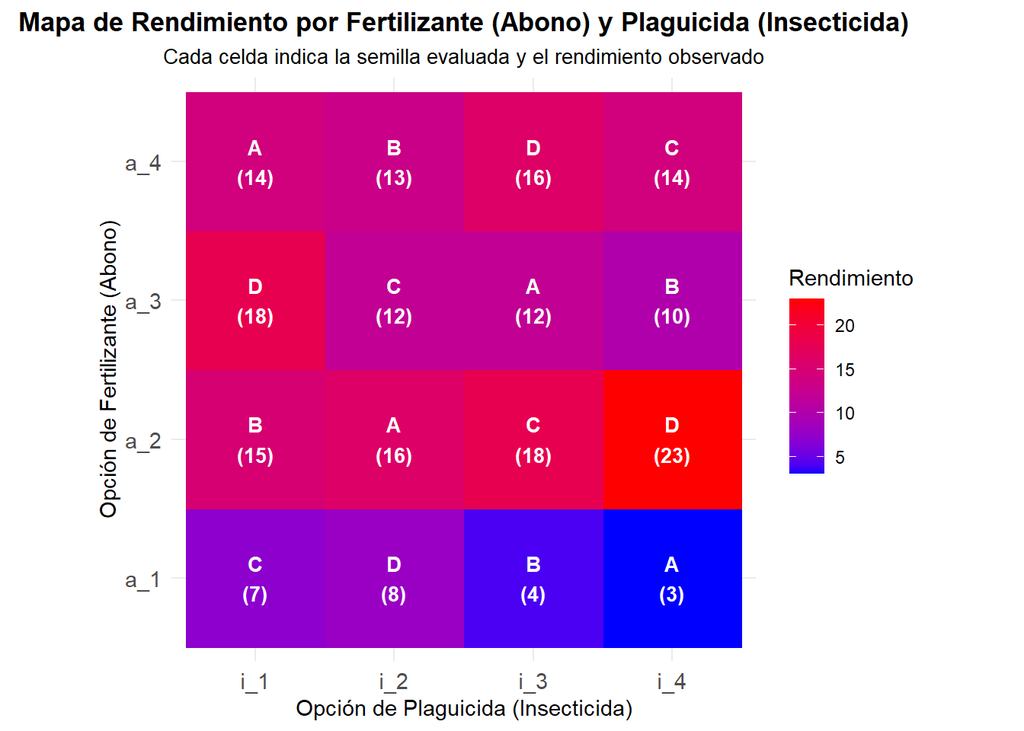

```r
ggplot(DCL, aes(x = Insecticida, y = Abono, fill = Respuesta)) +
  geom_raster() +
  geom_text(
    aes(label = paste0(toupper(Semilla), "\n(", Respuesta, ")")),
    color = "white",
    size = 3.6,
    fontface = "bold"
  ) +
  scale_fill_gradient(low = "blue", high = "red") +
  labs(
    title = "Mapa de Rendimiento por Fertilizante (Abono) y Plaguicida (Insecticida)",
    subtitle = "Cada celda indica la semilla evaluada y el rendimiento observado",
    x = "Opción de Plaguicida (Insecticida)",
    y = "Opción de Fertilizante (Abono)",
    fill = "Rendimiento"
  ) +
  theme_minimal() +
  theme(
    axis.text.x = element_text(size = 11),
    axis.text.y = element_text(size = 11),
    plot.title = element_text(hjust = 0.5, size = 13, face = "bold"),
    plot.subtitle = element_text(hjust = 0.5, size = 10)
  ) +
  coord_equal()
```

## Análisis de Varianza (ANOVA)

Ajustamos el modelo lineal aditivo para evaluar si existen diferencias significativas asociadas a los fertilizantes, a los plaguicidas o a las semillas.

```r
modelo_dcl <- aov(Respuesta ~ Abono + Insecticida + Semilla, data = DCL)
tabla_anova <- summary(modelo_dcl)
tabla_anova
```

```
##             Df Sum Sq Mean Sq F value   Pr(>F)
## Abono        3  329.7  109.90  47.523 0.000142 ***
## Insecticida  3    3.7    1.23   0.532 0.677183
## Semilla      3   78.2   26.06  11.270 0.007052 **
## Residuals    6   13.9    2.31
## ---
## Signif. codes:  0 '***' 0.001 '**' 0.01 '*' 0.05 '.' 0.1 ' ' 1
```

```r
f_critico <- qf(0.05, df1 = 3, df2 = 6, lower.tail = FALSE)
cat("Valor crítico F (alpha = 0.05, gl = 3, 6):", round(f_critico, 4), "\n")
```

```
## Valor crítico F (alpha = 0.05, gl = 3, 6): 4.7571
```

Lectura técnica del ANOVA:

Comparamos el estadístico $F$ de cada factor contra el valor crítico $F_{0.05,\, 3,\, 6} \approx 4.7571$ (y su respectivo $p$-valor). Los factores cuyo estadístico $F$ supera este umbral (o presentan $p < 0.05$) muestran evidencia estadística de afectar el rendimiento medio.

## Validación de supuestos

Antes de interpretar contrastes y rankings de opciones, verificamos que los supuestos sobre los residuos del modelo no se vean comprometidos:

Normalidad de residuos (Shapiro-Wilk): $H_0$ indica distribución normal de los errores.

Homocedasticidad (Prueba de Bartlett): $H_0$ indica varianzas homogéneas entre los grupos de tratamiento.

Independencia (Durbin-Watson): Valores cercanos a $2$ sugieren ausencia de autocorrelación serial en los residuos.

```r
residuos <- residuals(modelo_dcl)

# 1. Normalidad
sw_test <- shapiro.test(residuos)

# 2. Homocedasticidad
bart_test <- bartlett.test(residuos ~ DCL$Semilla)
chi_critico <- qchisq(0.05, df = 3, lower.tail = FALSE)

# 3. Independencia
dw_test <- durbinWatsonTest(modelo_dcl)

cat("--- Shapiro-Wilk (Normalidad) ---\n")
```

```
## --- Shapiro-Wilk (Normalidad) ---
```

```r
print(sw_test)
```

```
##
##  Shapiro-Wilk normality test
##
## data:  residuos
## W = 0.96304, p-value = 0.717
```

```r
cat("\n--- Bartlett (Homocedasticidad) ---\n")
```

```
##
## --- Bartlett (Homocedasticidad) ---
```

```r
print(bart_test)
```

```
##
##  Bartlett test of homogeneity of variances
##
## data:  residuos by DCL$Semilla
## Bartlett's K-squared = 3.6101, df = 3, p-value = 0.3068
```

```r
cat("Valor crítico Chi-cuadrado (alpha = 0.05, gl = 3):", round(chi_critico, 4), "\n")
```

```
## Valor crítico Chi-cuadrado (alpha = 0.05, gl = 3): 7.8147
```

```r
cat("\n--- Durbin-Watson (Independencia) ---\n")
```

```
##
## --- Durbin-Watson (Independencia) ---
```

```r
print(dw_test)
```

```
##  lag Autocorrelation D-W Statistic p-value
##    1      -0.2376126      2.445946   0.864
##  Alternative hypothesis: rho != 0
```

## Comparaciones múltiples: LSD y ajuste de Bonferroni

Cuando el ANOVA detecta diferencias entre niveles, las pruebas post-hoc permiten discernir qué opciones destacan y cuáles se agrupan estadísticamente. Comparamos:

LSD (Least Significant Difference): Mayor potencia para detectar diferencias, pero con mayor probabilidad acumulada de falsos positivos si se hacen múltiples contrastes.

Bonferroni: Más conservadora; ajusta el nivel de significancia dividiendo $\alpha$ entre el número de comparaciones por pares (con 4 niveles hay $\binom{4}{2} = 6$ pares, por lo que $\alpha_{\text{ajustado}} = 0.05 / 6 \approx 0.0083$).

Fertilizante / Abono

```r
lsd_abono_res <- LSD.test(y = modelo_dcl, trt = "Abono", group = TRUE, console = TRUE)
```

```
##
## Study: modelo_dcl ~ "Abono"
##
## LSD t Test for Respuesta
##
## Mean Square Error:  2.3125
##
## Abono,  means and individual ( 95 %) CI
##
##     Respuesta      std r        se       LCL       UCL Min Max   Q25  Q50   Q75
## a_1      5.50 2.380476 4 0.7603453  3.639502  7.360498   3   8  3.75  5.5  7.25
## a_2     18.00 3.559026 4 0.7603453 16.139502 19.860498  15  23 15.75 17.0 19.25
## a_3     13.00 3.464102 4 0.7603453 11.139502 14.860498  10  18 11.50 12.0 13.50
## a_4     14.25 1.258306 4 0.7603453 12.389502 16.110498  13  16 13.75 14.0 14.50
##
## Alpha: 0.05 ; DF Error: 6
## Critical Value of t: 2.446912
##
## least Significant Difference: 2.631141
##
## Treatments with the same letter are not significantly different.
##
##     Respuesta groups
## a_2     18.00      a
## a_4     14.25      b
## a_3     13.00      b
## a_1      5.50      c
```

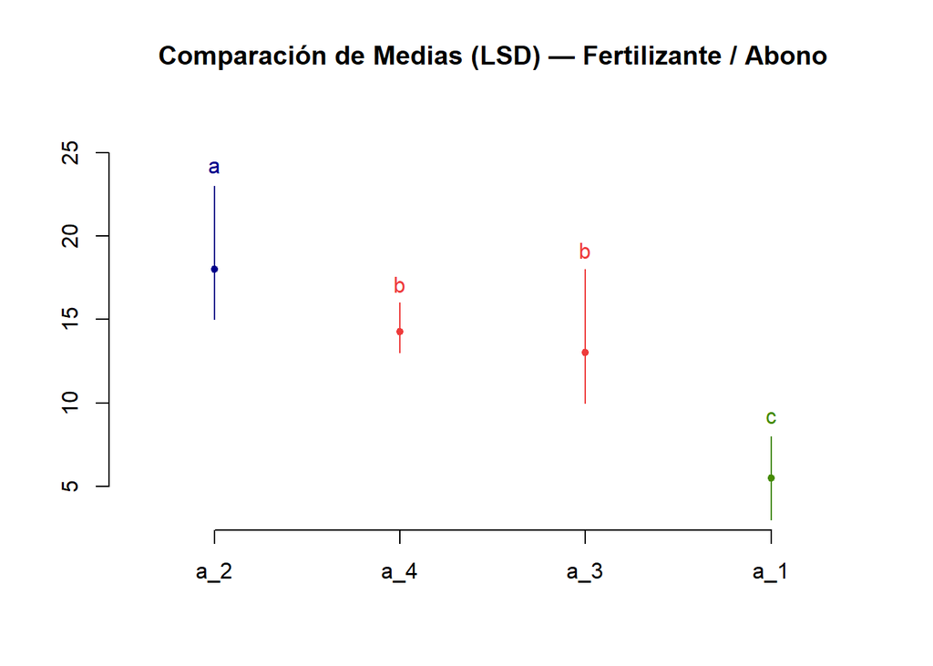

```r
plot(lsd_abono_res, main = "Comparación de Medias (LSD) — Fertilizante / Abono")
```

```r
bonf_abono_res <- LSD.test(y = modelo_dcl, trt = "Abono", p.adj = "bon", group = TRUE, console = TRUE)
```

```
##
## Study: modelo_dcl ~ "Abono"
##
## LSD t Test for Respuesta
## P value adjustment method: bonferroni
##
## Mean Square Error:  2.3125
##
## Abono,  means and individual ( 95 %) CI
##
##     Respuesta      std r        se       LCL       UCL Min Max   Q25  Q50   Q75
## a_1      5.50 2.380476 4 0.7603453  3.639502  7.360498   3   8  3.75  5.5  7.25
## a_2     18.00 3.559026 4 0.7603453 16.139502 19.860498  15  23 15.75 17.0 19.25
## a_3     13.00 3.464102 4 0.7603453 11.139502 14.860498  10  18 11.50 12.0 13.50
## a_4     14.25 1.258306 4 0.7603453 12.389502 16.110498  13  16 13.75 14.0 14.50
##
## Alpha: 0.05 ; DF Error: 6
## Critical Value of t: 3.862991
##
## Minimum Significant Difference: 4.153838
##
## Treatments with the same letter are not significantly different.
##
##     Respuesta groups
## a_2     18.00      a
## a_4     14.25     ab
## a_3     13.00      b
## a_1      5.50      c
```

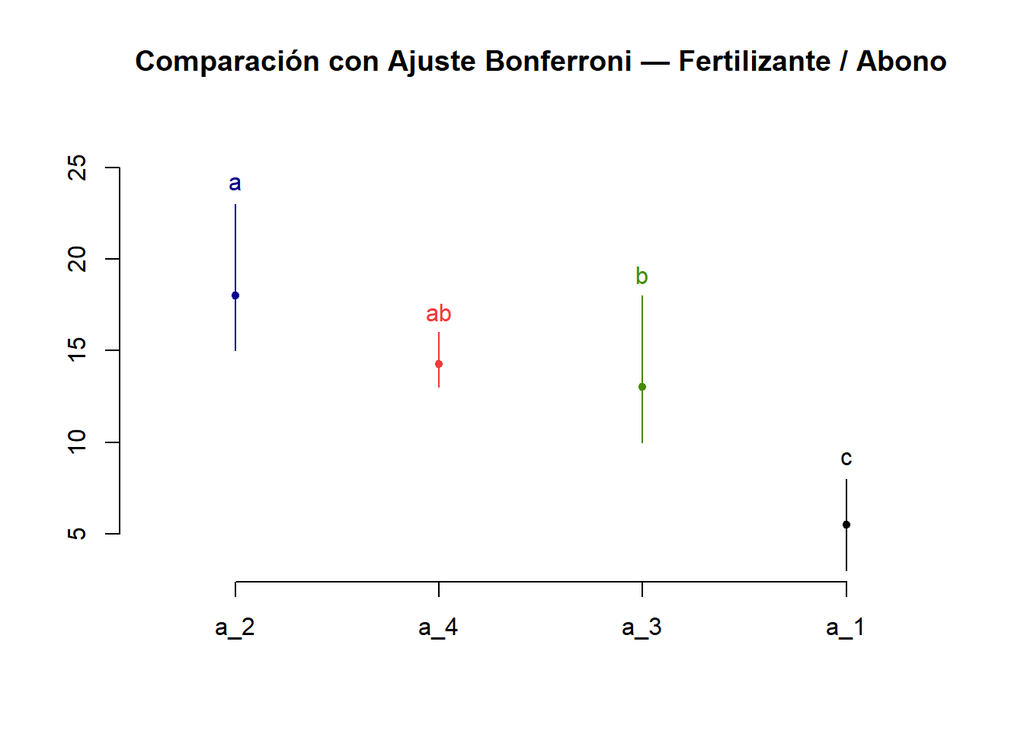

```r
plot(bonf_abono_res, main = "Comparación con Ajuste Bonferroni — Fertilizante / Abono")
```

Semilla

```r
lsd_semilla_res <- LSD.test(y = modelo_dcl, trt = "Semilla", group = TRUE, console = TRUE)
```

```
##
## Study: modelo_dcl ~ "Semilla"
##
## LSD t Test for Respuesta
##
## Mean Square Error:  2.3125
##
## Semilla,  means and individual ( 95 %) CI
##
##   Respuesta      std r        se       LCL     UCL Min Max   Q25  Q50   Q75
## a     11.25 5.737305 4 0.7603453  9.389502 13.1105   3  16  9.75 13.0 14.50
## b     10.50 4.795832 4 0.7603453  8.639502 12.3605   4  15  8.50 11.5 13.50
## c     12.75 4.573474 4 0.7603453 10.889502 14.6105   7  18 10.75 13.0 15.00
## d     16.25 6.238322 4 0.7603453 14.389502 18.1105   8  23 14.00 17.0 19.25
##
## Alpha: 0.05 ; DF Error: 6
## Critical Value of t: 2.446912
##
## least Significant Difference: 2.631141
##
## Treatments with the same letter are not significantly different.
##
##   Respuesta groups
## d     16.25      a
## c     12.75      b
## a     11.25      b
## b     10.50      b
```

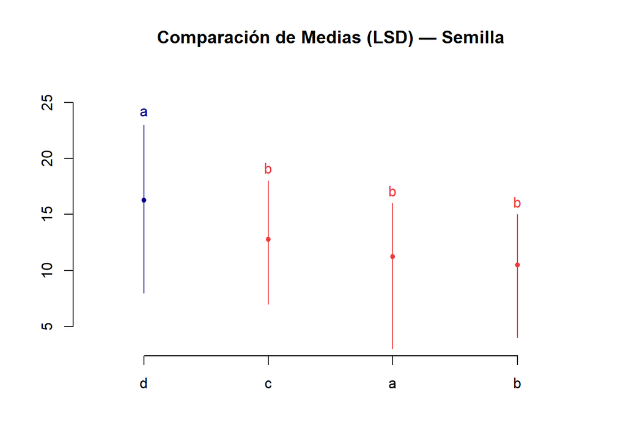

```r
plot(lsd_semilla_res, main = "Comparación de Medias (LSD) — Semilla")
```

```r
bonf_semilla_res <- LSD.test(y = modelo_dcl, trt = "Semilla", p.adj = "bon", group = TRUE, console = TRUE)
```

```
##
## Study: modelo_dcl ~ "Semilla"
##
## LSD t Test for Respuesta
## P value adjustment method: bonferroni
##
## Mean Square Error:  2.3125
##
## Semilla,  means and individual ( 95 %) CI
##
##   Respuesta      std r        se       LCL     UCL Min Max   Q25  Q50   Q75
## a     11.25 5.737305 4 0.7603453  9.389502 13.1105   3  16  9.75 13.0 14.50
## b     10.50 4.795832 4 0.7603453  8.639502 12.3605   4  15  8.50 11.5 13.50
## c     12.75 4.573474 4 0.7603453 10.889502 14.6105   7  18 10.75 13.0 15.00
## d     16.25 6.238322 4 0.7603453 14.389502 18.1105   8  23 14.00 17.0 19.25
##
## Alpha: 0.05 ; DF Error: 6
## Critical Value of t: 3.862991
##
## Minimum Significant Difference: 4.153838
##
## Treatments with the same letter are not significantly different.
##
##   Respuesta groups
## d     16.25      a
## c     12.75     ab
## a     11.25      b
## b     10.50      b
```

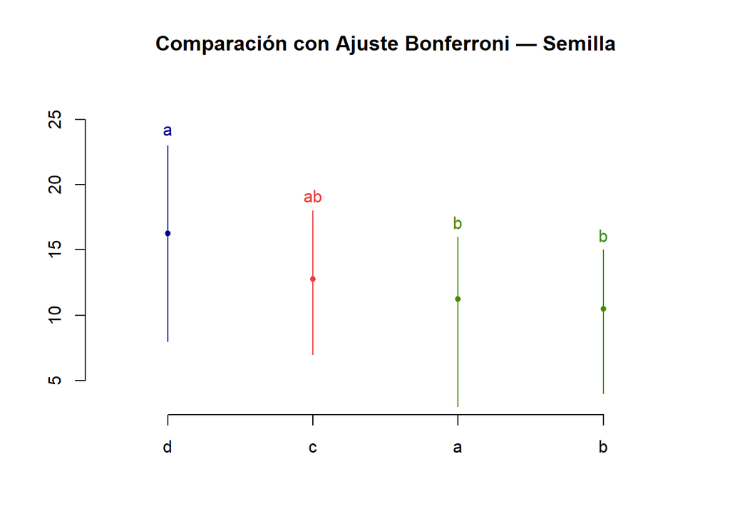

```r
plot(bonf_semilla_res, main = "Comparación con Ajuste Bonferroni — Semilla")
```

# Conclusiones y Recomendaciones de Inversión

El contraste entre LSD y Bonferroni confirma diferencias claras entre los niveles extremos y aporta prudencia al agrupar opciones intermedias: LSD identifica más contrastes significativos, mientras que Bonferroni exige mayor margen de evidencia antes de declarar superioridad entre dos insumos cercanos.

En los datos analizados, el nivel de fertilizante a2 y la variedad de semilla s4 sobresalen en rendimiento frente al resto de alternativas evaluadas

Antes de incrementar el gasto en cambios de plaguicida sin respaldo de presión de plaga, se deberia priorizar, validar y escalar las combinaciones ganadoras de semilla y fertilizante en lotes de prueba

Si cambiar de proveedor o formulación implica un desembolso elevado o un riesgo operativo importante, se recomienda utilizar un criterio mas conservador como el de Bonferroni para exigir diferencias robustas antes de migrar a escala comercial.

El rendimiento estadístico identifica qué insumo produce más; para cerrar la decisión financiera, cruza estos grupos de rendimiento con el costo por hectárea, la disponibilidad del insumo y el margen esperado en la operación.